# Assignment 17: Data Simulation

*How to do it?*:

- Open the Rmarkdown file of this assignment (link) in Rstudio.
- Right under each **question**, insert a code chunk (you can use the hotkey `Ctrl + Alt + I` to add a code chunk) and code the solution for the question.
- `Knit` the rmarkdown file (hotkey: `Ctrl + Alt + K`) to export an html.
- Publish the html file to your Githiub Page.

*Submission*: Submit the link on Github of the assignment to Canvas

**Notice:** *In this assignment, all the plot should have title, caption, and axis labels.*

### 1. Simulating Data for a model

Suppose we want to simulate data from the following linear model

$$y = 2 + 3 x + \epsilon$$
where $\epsilon \sim N(0, 1)$.

To simulate data, we first need specify values for $x$. We use `rnorm` to generate data from the normal distribution and `runif` to generate data from the uniform distribution.

```r
n = 1000
x = runif(n = n, 0, 10)
e = rnorm(n=100, mean = 0, sd = 1)
y = 2+3*x + e
```

Use the linear model to estimate the coefficient with the simulated the data.

```r
lm(y~x)
```

```
##
## Call:
## lm(formula = y ~ x)
##
## Coefficients:
## (Intercept)            x
##       2.027        3.003
```

We see that the linear model does a very good job estimating the true value of the coefficients.

Do the follows.

- Simulate data for the following model and use linear model to recover the coefficients. How well the linear model fits the data? Hint: Use `lm(y ~ x1 + x2)` for multiple linear regression.

$$y = 2 + 3 x_1 + 4x_2 + \epsilon$$
where $\epsilon \sim N(0, 2)$.

```r
# Simulating 1,000 points of data for the linear model.
n = 1000
x_1 = runif(n = n, 0, 2)
x_2 = runif(n = n, 0, 2)

# Establishing a value for epsilon and creating the model.
e = rnorm(n=100, mean = 0, sd = 1)
y = 2+3*x_1+4*x_2 + e
```

```r
# Calling the multivariate linear model to display estimates for the coefficients.
lm(y ~ x_1+x_2)
```

```
##
## Call:
## lm(formula = y ~ x_1 + x_2)
##
## Coefficients:
## (Intercept)          x_1          x_2
##       2.007        3.001        4.009
```

### 2. Simulating Data to test the Central Limit Theorem

The central limit theorem says that the sample means of any distribution follows the normal distribution with the same population mean. Do the follows to verify the theorem

- Generate m = 10,000 samples from uniform distribution, each sample has the size $n = 1000$
- Calculate the means of all the samples

```r
#Initializing an empty list
sample_avg <- list()

# Creating a loop to make 10,000 samples of size 1,000.
for (i in 1:10000)
{
  y = sample(runif(n = 1000),replace = TRUE)
  avg = mean(y)
  sample_avg <- append(sample_avg,avg)
}
```

- Plot the histogram of the means and verify that the histogram shows the normal distribution of the means.

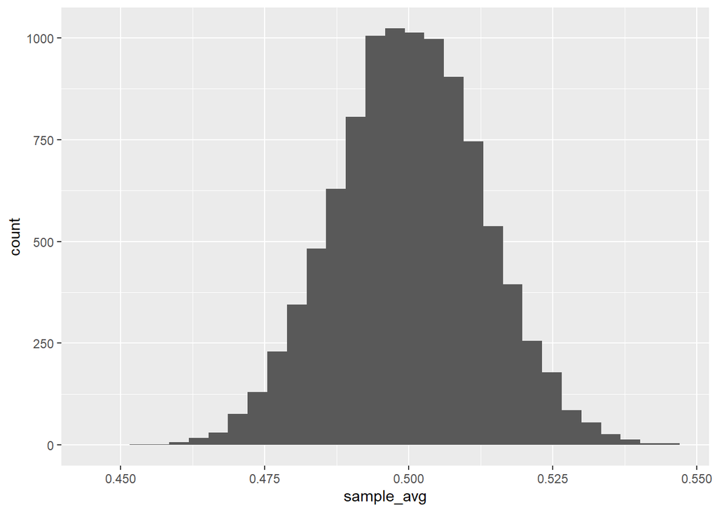

```r
# Plotting the histogram if the means to verify the central limit theorem. Particularly, that the sample means follow a normal distribution. Note that I needed to convert the contents of the list to numeric before creating the plot.

sample_avg = as.numeric(sample_avg)
library(ggplot2)
ggplot()+
  geom_histogram(aes(x = sample_avg))
```

Redo the above steps for the distribution of the number of values getting when rolling a die. [Hint: Use `sample(1, 6, n, replace = TRUE)` to generate samples from rolling a die]

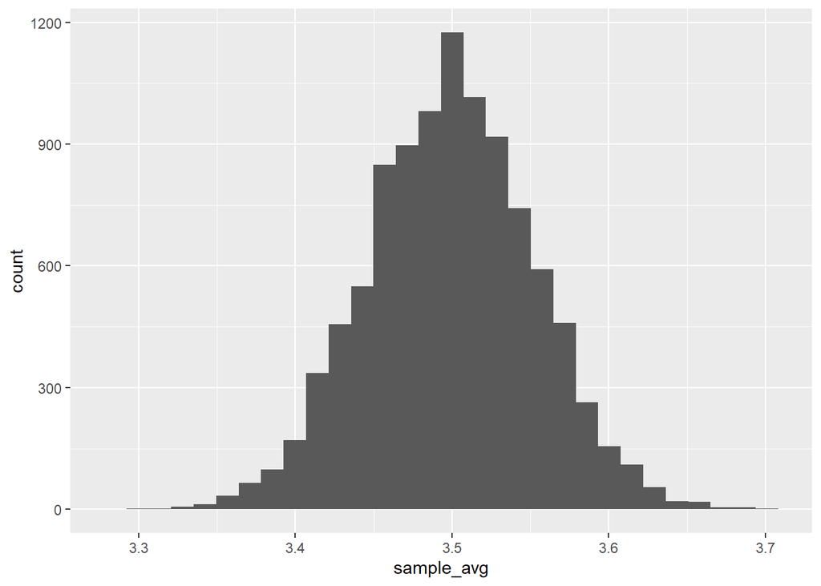

```r
#Initializing an empty list
sample_avg <- list()
n = 1000

# recording the average value in each sample of 1,000 10,000 times.
for (i in 1:10000)
{
  y = sample(c(1:6),n,replace = TRUE)
  avg = mean(y)
  sample_avg <- append(sample_avg,avg)
}

# Converting the class of the list to numeric and creating the histogram.
sample_avg = as.numeric(sample_avg)
ggplot()+
  geom_histogram(aes(x = sample_avg))
```

### 3. (Monte Carlo Methods) Estimating Pi

[figure not shown]

Do the following to estimate $\pi$

- Generating n = 1000 values of $x$ from the uniform distribution from -1 to 1 using `runif`
- Generating n = 1000 values of $y$ from the uniform distribution from -1 to 1 using `runif`
- Counting the number of points $(x,y)$ within the circle by counting the number of points such that $x^2 + y^2 \leq 1$.
- We have the area of a circle is calculated by $A_1 = \pi r^2$, and the area of the bounding square is $A_2 = 4r^2$. We have

$$\frac{\pi}{4} = \frac{\pi r^2}{4r^2} = \frac{A_1}{A_2} \approx
\frac{\text{Number of Points within the circle}}{\text{Total Number of
Points}}$$

```r
# Plotting 1,000 points in a grid using the uniform distribution.

set.seed(64)
n = 1000

x = runif(n,-1,1)
y = runif(n,-1,1)

# Creating a data frame to hold values for x and y. A test is performed to see if a point falls within a unit circle.
df <- data.frame(x = x, y = y, sum_sq = (x)^2+(y)^2)
df$in_circle = ifelse(df$sum_sq > 1, 0, 1)

# Displaying the data frame.
head(df)
```

```
##            x           y    sum_sq in_circle
## 1 -0.9123566  0.02354567 0.8329490         1
## 2  0.6544126 -0.40252946 0.5902858         1
## 3 -0.9132672 -0.41199706 1.0037985         0
## 4  0.9786663 -0.24518275 1.0179024         0
## 5 -0.8203075 -0.28357269 0.7533178         1
## 6  0.6353801  0.94153717 1.2902001         0
```

```r
# Solving for pi.
a_1 = sum(df$in_circle)
a_2 = n

# The value of pi has been estimated at approximately 3.152 using n = 1,000 points.
pi = 4*(a_1/a_2)
pi
```

```
## [1] 3.152
```

- Estimating $\pi$ from the above equation.
- Increase the value of $n$ for more accurate estimation for $\pi$.

```r
# Increasing the value of n to 1,000,000 to improve the accuracy of the estimation for pi.
set.seed(64)
n = 1000000

# Creating the grid with uniform distributions for x and y.
x = runif(n,-1,1)
y = runif(n,-1,1)

# Creating a data frame to hold values for x,y, and testing if the point falls within the circle.
df <- data.frame(x = x, y = y, sum_sq = (x)^2+(y)^2)
df$in_circle = ifelse(df$sum_sq > 1, 0, 1)

# Setting up the equation and solving for pi
a_1 = sum(df$in_circle)
a_2 = n

# As expected, the accuracy of the estimation for pi has increased greatly from 3.152 to 3.143384.
pi = 4*(a_1/a_2)
pi
```

```
## [1] 3.143384
```